# Data-Wrangling-project

#### ROI Analysis with coupons

```r
setDTthreads(threads = getOption("datatable.threads"))
options(datatable.allow.cartesian=TRUE)

analysis_data_with_coupons <- dt_selected_transactions[
  dt_selected_coupon_redemptions,
  on = "household_id",
  nomatch = 0L
]

campaign_impact <- analysis_data_with_coupons[, .(
    total_sales = sum(sales_value, na.rm = TRUE),
    total_transactions = .N,
    avg_sales_per_transaction = mean(sales_value, na.rm = TRUE),
    total_quantity = sum(quantity, na.rm = TRUE),
    total_campaign_cost = sum(campaign_cost, na.rm = TRUE),
    net_profit = sum(net_profit, na.rm = TRUE),
    ROI = (sum(net_profit, na.rm = TRUE) / sum(campaign_cost, na.rm = TRUE)) * 100
  ), by = campaign_id
][order(-total_sales)]


campaign_impact <- campaign_impact[
  dt_selected_campaign_descriptions,
  on = "campaign_id"
]


print(head(campaign_impact))
```

```
##    campaign_id total_sales total_transactions avg_sales_per_transaction
## 1:           1     1714.35                618                  2.774029
## 2:           2    15562.71               6348                  2.451593
## 3:           3     8083.16               2766                  2.922328
## 4:           4    34284.35               9792                  3.501261
## 5:           5    82600.86              21321                  3.874155
## 6:           6     3138.44               1245                  2.520835
##    total_quantity total_campaign_cost net_profit       ROI campaign_type
## 1:            741              350.98    506.195 144.22332        Type B
## 2:         825016             4281.28   3500.075  81.75300        Type B
## 3:         510149             2232.02   1809.560  81.07275        Type C
## 4:        1873063             7383.03   9759.145 132.18347        Type B
## 5:        5522517            13404.28  27896.150 208.11375        Type B
## 6:           1651              548.14   1021.080 186.28088        Type C
##    start_date   end_date
## 1: 2017-03-03 2017-04-09
## 2: 2017-03-08 2017-04-09
## 3: 2017-03-13 2017-05-08
## 4: 2017-03-29 2017-04-30
## 5: 2017-04-03 2017-05-07
## 6: 2017-04-19 2017-05-21
```

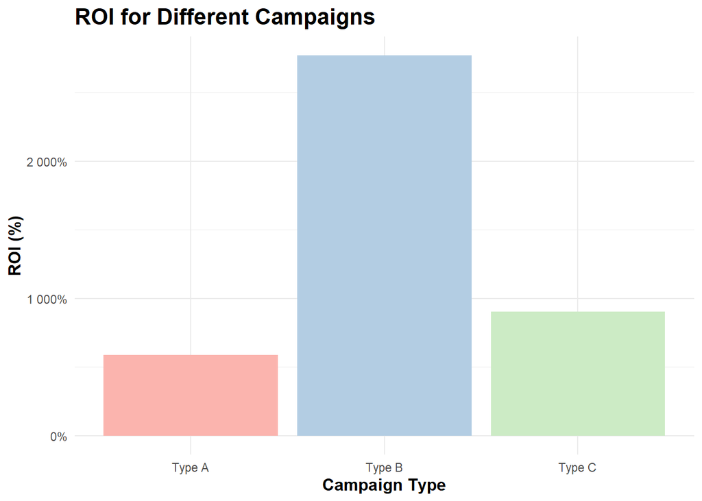

```r
ggplot(campaign_impact, aes(x = campaign_type, y = ROI, fill = campaign_type)) +
  geom_bar(stat = "identity", show.legend = FALSE) +
  scale_fill_brewer(palette = "Pastel1") +
  labs(title = "ROI for Different Campaigns",
       x = "Campaign Type",
       y = "ROI (%)") +
  theme_minimal()  +
    theme(
    plot.title = element_text(face = "bold", size = 16),  # Title settings
    axis.title.x = element_text(face = "bold", size = 12),  # X-axis label settings
    axis.title.y = element_text(face = "bold", size = 12)  # Y-axis label settings
  ) +
  scale_y_continuous(labels = scales::percent_format(scale = 1))
```

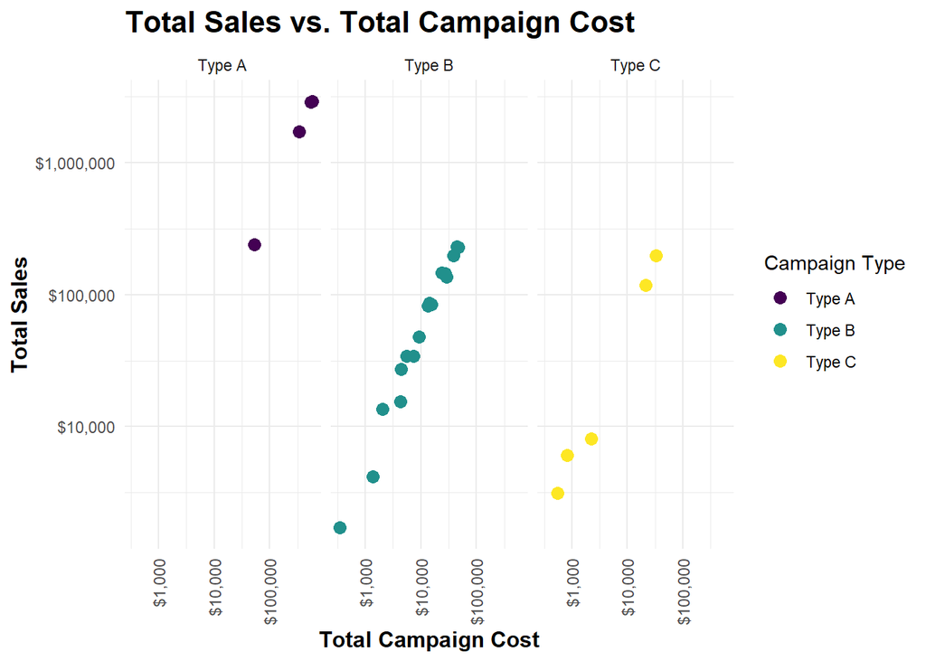

```r
ggplot(campaign_impact, aes(x = total_campaign_cost, y = total_sales, color = campaign_type)) +
  geom_point(size = 3) +
  scale_fill_brewer(palette = "Pastel1") +
  labs(title = "Total Sales vs. Total Campaign Cost",
       x = "Total Campaign Cost",
       y = "Total Sales") +
  theme_minimal() +
  theme(
    plot.title = element_text(face = "bold", size = 16),
    axis.title.x = element_text(face = "bold", size = 12),
    axis.title.y = element_text(face = "bold", size = 12),
    axis.text.x = element_text(angle = 90, vjust = 0.5, hjust = 1)
  ) +
  facet_wrap(~campaign_type) +
  scale_y_continuous(labels = scales::dollar, trans = "log10") +  # Logarithmic scale on y-axis
  scale_x_continuous(labels = scales::dollar, trans = "log10") +  # Logarithmic scale on x-axis
  guides(color = guide_legend(title = "Campaign Type"))
```

## Conversion Rate

```r
targeted_households <- dt_selected_campaigns[, .N, by = campaign_id]

converting_households <- dt_selected_transactions[dt_selected_campaigns, on = "household_id", nomatch = 0L
                                                  ][, .N, by = campaign_id]

conversion_rate_data <- targeted_households[converting_households, on = "campaign_id"
                                            ][, conversion_rate := (N / i.N) * 100]


conversion_rate_data <- conversion_rate_data[dt_selected_campaign_descriptions, on = "campaign_id"]

conversion_rate_data
```

```
##     campaign_id    N     i.N conversion_rate campaign_type start_date
##  1:           1   13   11887      0.10936317        Type B 2017-03-03
##  2:           2   48   37017      0.12967015        Type B 2017-03-08
##  3:           3   12   17657      0.06796171        Type C 2017-03-13
##  4:           4   81   87804      0.09225092        Type B 2017-03-29
##  5:           5  166  214201      0.07749730        Type B 2017-04-03
##  6:           6   65  100710      0.06454175        Type C 2017-04-19
##  7:           7  198  225118      0.08795387        Type B 2017-04-24
##  8:           8 1076  982730      0.10949091        Type A 2017-05-08
##  9:           9  176  166277      0.10584747        Type B 2017-05-31
## 10:          10  123  163270      0.07533533        Type B 2017-06-28
## 11:          11  214  280825      0.07620404        Type B 2017-07-12
## 12:          12  170  223674      0.07600347        Type B 2017-07-12
## 13:          13 1077 1042566      0.10330281        Type A 2017-08-08
## 14:          14  224  322977      0.06935478        Type C 2017-09-04
```

[output cut: 43 more lines]

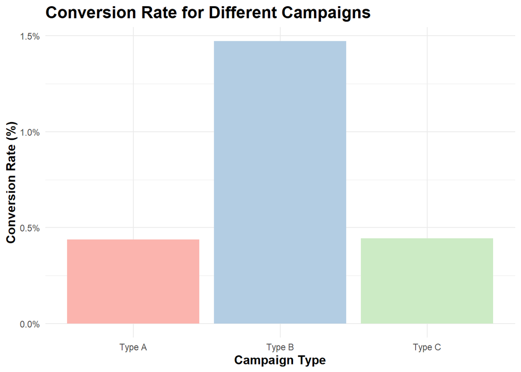

```r
# Visualization of conversion rates per campaign without numbers on top
conversion_rate_data <- targeted_households[converting_households, on = "campaign_id"
                                            ][, conversion_rate := (N / i.N) * 100]

# Merge with campaign descriptions for better readability in plots
conversion_rate_data <- conversion_rate_data[dt_selected_campaign_descriptions, on = "campaign_id"]

# Visualization of conversion rates per campaign without numbers on top
ggplot(conversion_rate_data, aes(x = reorder(campaign_type, -conversion_rate), y = conversion_rate, fill = campaign_type)) +
  geom_bar(stat = "identity", show.legend = FALSE) +
  scale_fill_brewer(palette = "Pastel1") +
  labs(title = "Conversion Rate for Different Campaigns",
       x = "Campaign Type",
       y = "Conversion Rate (%)") +
  theme_minimal() +
    theme(
    plot.title = element_text(face = "bold", size = 16),  # Title settings
    axis.title.x = element_text(face = "bold", size = 12),  # X-axis label settings
    axis.title.y = element_text(face = "bold", size = 12)  # Y-axis label settings
  ) +
  scale_y_continuous(labels = scales::percent_format(scale=1))
```

## Summary

### 2. Demographics Impact on Purchases

1. Transactions with Coupons
- Age groups 45-54 and 35-44 show high total sales across various income brackets and campaign types.
2. Transactions without Coupons
- Again, age groups 45-54 and 35-44 dominate in sales, indicating they are key demographics.

#### Recommendations:

- Target Key Demographics: Tailor campaigns to age groups 45-54 and 35-44, as they tend to generate higher sales.
- Diversify Offerings: Develop strategies to engage other age and income demographics to diversify customer base and increase sales.

### Additional Strategic Recommendations:

1. **Seasonality Analysis:** Analyze purchase trends to understand seasonal impacts on sales and tailor campaigns accordingly.
2. **Multi-Channel Approach:** Employ various channels (email, SMS, app notifications) to engage customers based on their preferred communication medium.
3. **Competitive Analysis:** Keep an eye on competitors’ strategies and ensure your campaigns offer something unique or better value.
4. **Product Bundling:** Use data to identify products that are commonly purchased together and create bundled offers.

### Closing Thoughts:

It’s imperative to continually analyze data post-campaign and adjust strategies accordingly. The above recommendations provide a structured approach, but the dynamic nature of consumer behavior necessitates flexibility and adaptability in strategies. Always keep the customer at the center of decision-making and strive to deliver value in a way that also aligns with business objectives.